# Reliever Report: Antonio Menendez

### Spin Axis Distributions

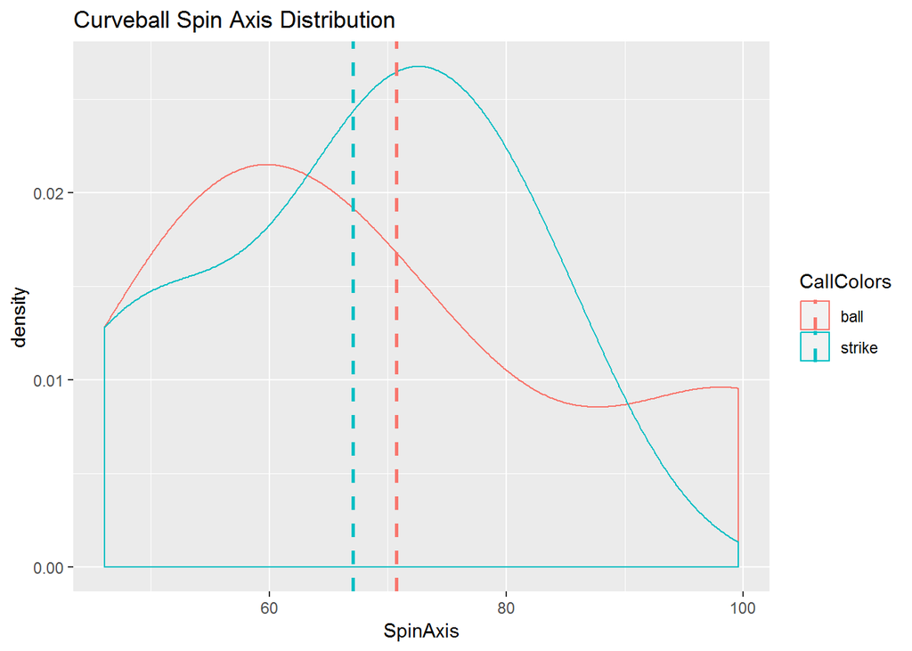

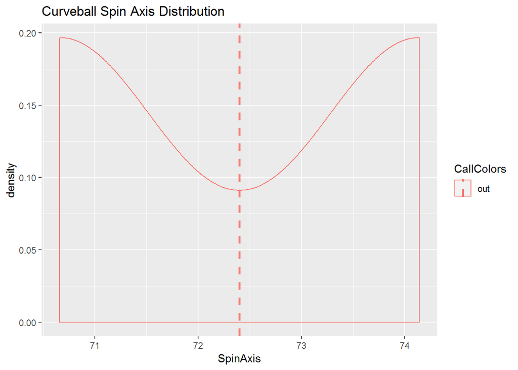

Spin axis density shows that curveballs are mostly likely to result in strikes with a spin axis between 65 and 90 degrees. This is an ideal range, as it also results most often in strikes.

No curveballs have resulted in hits.

## Release Heights

### Balls and Strikes

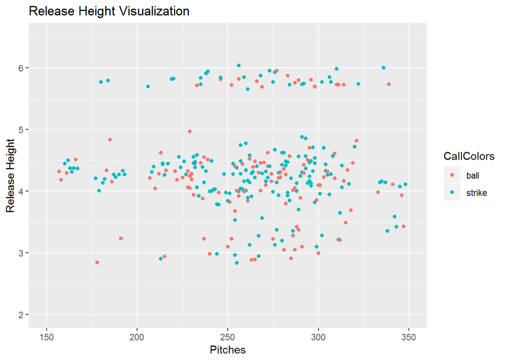

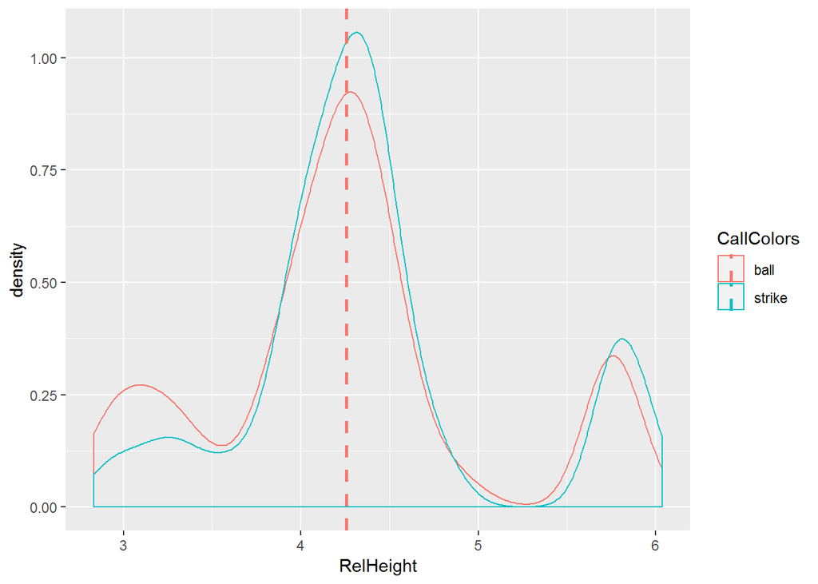

Distributions of release heights for balls and strikes are nearly identical, with slightly more balls occurring proportionally at a release height of around 3 ft and more strikes occurring proportionally at a release height of around 4.25 and above 5.75.

### Hits and Outs

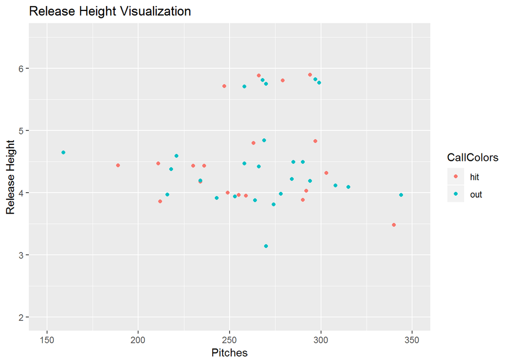

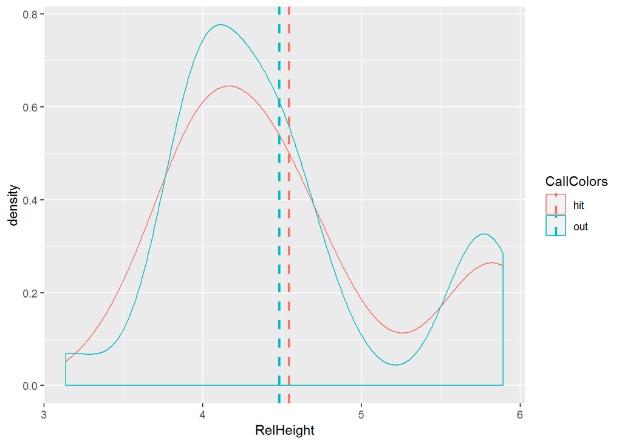

Balls thrown from a release height below 3.5 are being put in play proportionally less than in other slots. These pitches are also thrown out of the zone slightly more often than others, but there does seem to be an overall trend here.

## Spin Axis

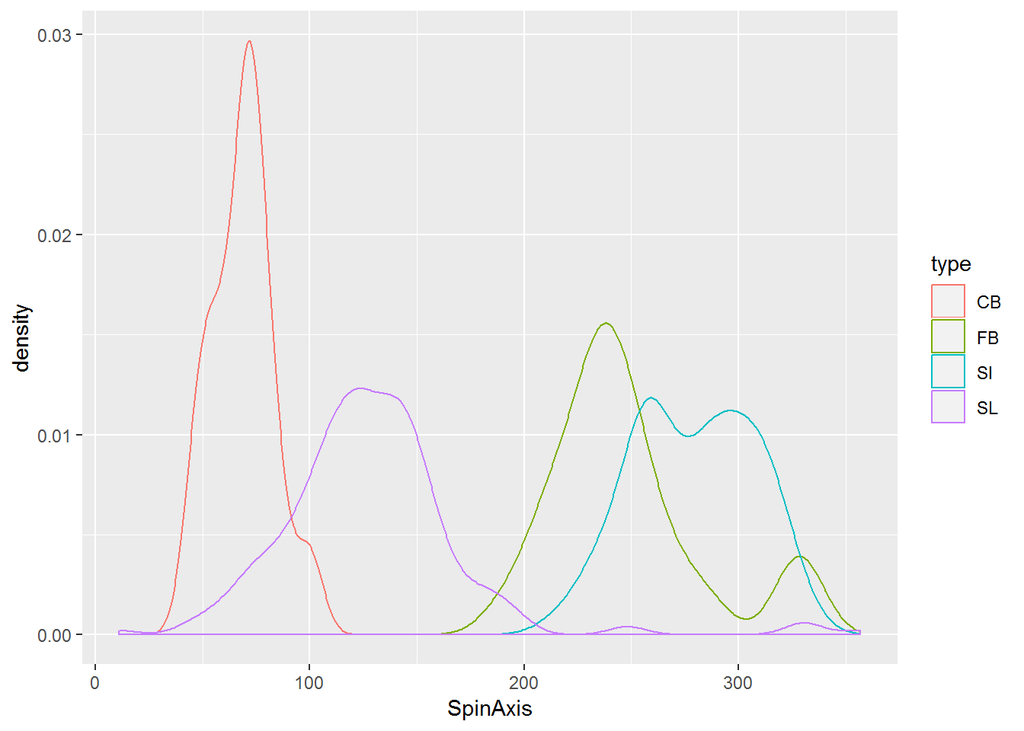

Sliders are being thrown most often at a 100-150 degrees spin axis.

Fastballs are being thrown at an approximate 250 spin axis, with some occurring around 325.

Sinkers are being thrown at a spin axis range between 250 to 325.

Curveballs are most often being thrown at a 50-100 degree spin axis.

## Prediction

### Called Strikes

```
##
## Classification tree:
## tree(formula = as.factor(StrikeCalled) ~ RelHeight + RelSide +
##     RelSpeed + VertRelAngle + HorzRelAngle + Extension + VertBreak +
##     HorzBreak + SpinRate + SpinAxis + as.factor(type) + as.factor(loc),
##     data = lefties)
## Variables actually used in tree construction:
## [1] "as.factor(loc)" "Extension"      "RelSide"        "VertRelAngle"
## [5] "RelSpeed"       "SpinRate"       "VertBreak"      "RelHeight"
## Number of terminal nodes:  9
## Residual mean deviance:  0.1936 = 21.29 / 110
## Misclassification error rate: 0.05042 = 6 / 119
```

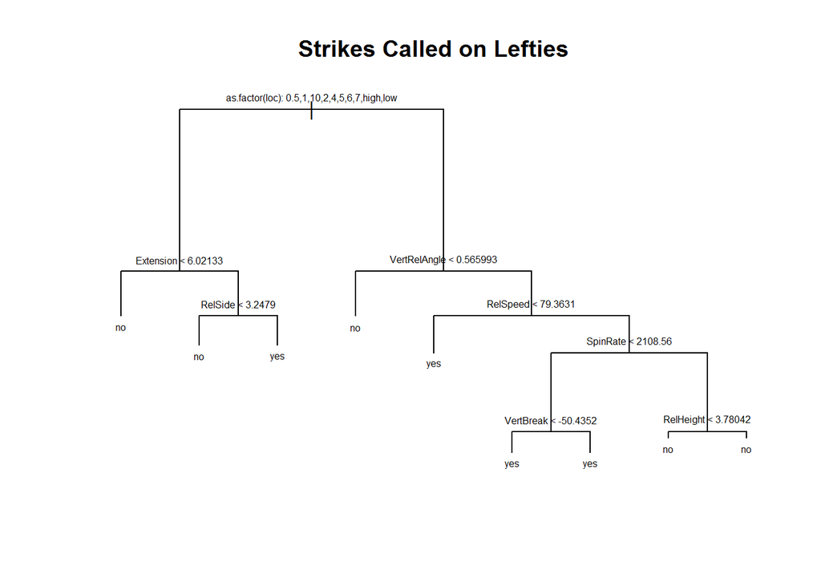

```
##
## Classification tree:
## tree(formula = as.factor(StrikeCalled) ~ RelHeight + RelSide +
##     RelSpeed + VertRelAngle + HorzRelAngle + Extension + VertBreak +
##     HorzBreak + SpinRate + SpinAxis + as.factor(type) + as.factor(loc),
##     data = righties)
## Variables actually used in tree construction:
## [1] "as.factor(loc)" "VertRelAngle"   "VertBreak"      "RelSpeed"
## [5] "HorzRelAngle"   "HorzBreak"      "RelSide"        "RelHeight"
## [9] "SpinRate"
## Number of terminal nodes:  16
## Residual mean deviance:  0.4245 = 57.73 / 136
## Misclassification error rate: 0.1053 = 16 / 152
```

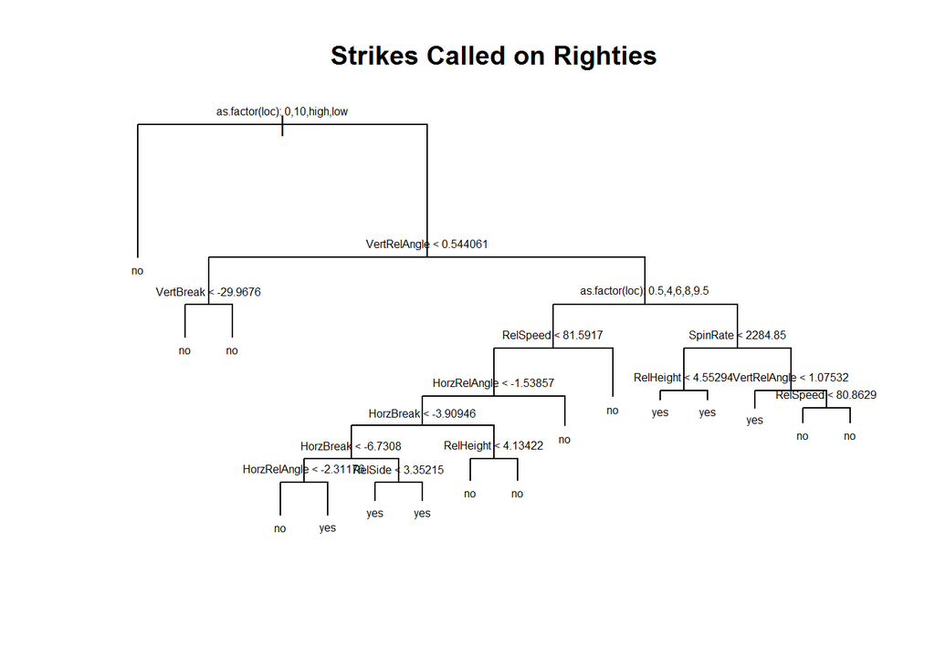

The most important indicactor of strikes being called on lefties is pitch location. Location is also the most important indicator of strikes being called on righties, with pitches being thrown low, high, or more than a ball inside or off of the plate resulting in a terminal node, as expected.

### Strikes Swinging

```
##
## Classification tree:
## tree(formula = as.factor(StrikeSwinging) ~ RelHeight + RelSide +
##     RelSpeed + VertRelAngle + HorzRelAngle + Extension + VertBreak +
##     HorzBreak + SpinRate + SpinAxis + as.factor(type) + as.factor(loc),
##     data = lefties)
## Variables actually used in tree construction:
## [1] "as.factor(loc)" "SpinRate"       "RelSide"        "HorzRelAngle"
## [5] "Extension"
## Number of terminal nodes:  6
## Residual mean deviance:  0.1472 = 16.64 / 113
## Misclassification error rate: 0.03361 = 4 / 119
```

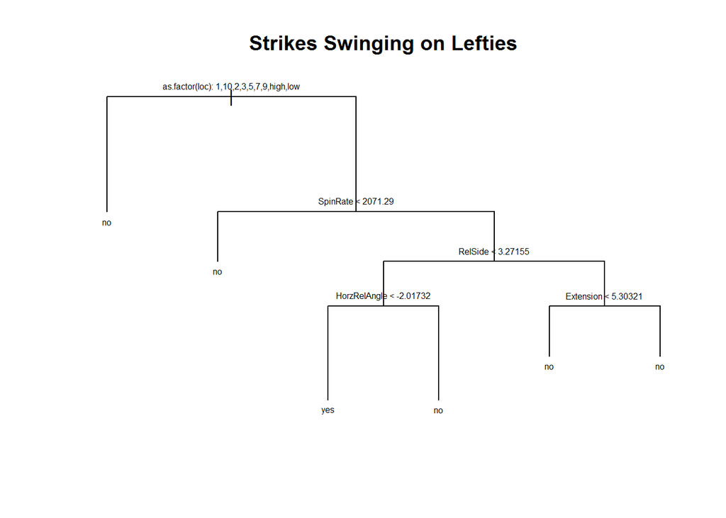

```
##
## Classification tree:
## tree(formula = as.factor(StrikeSwinging) ~ RelHeight + RelSide +
##     RelSpeed + VertRelAngle + HorzRelAngle + Extension + VertBreak +
##     HorzBreak + SpinRate + SpinAxis + as.factor(type) + as.factor(loc),
##     data = righties)
## Variables actually used in tree construction:
## [1] "VertRelAngle"   "RelSpeed"       "RelHeight"      "Extension"
## [5] "as.factor(loc)" "HorzRelAngle"   "HorzBreak"      "SpinRate"
## [9] "VertBreak"
## Number of terminal nodes:  13
## Residual mean deviance:  0.3278 = 45.57 / 139
## Misclassification error rate: 0.08553 = 13 / 152
```

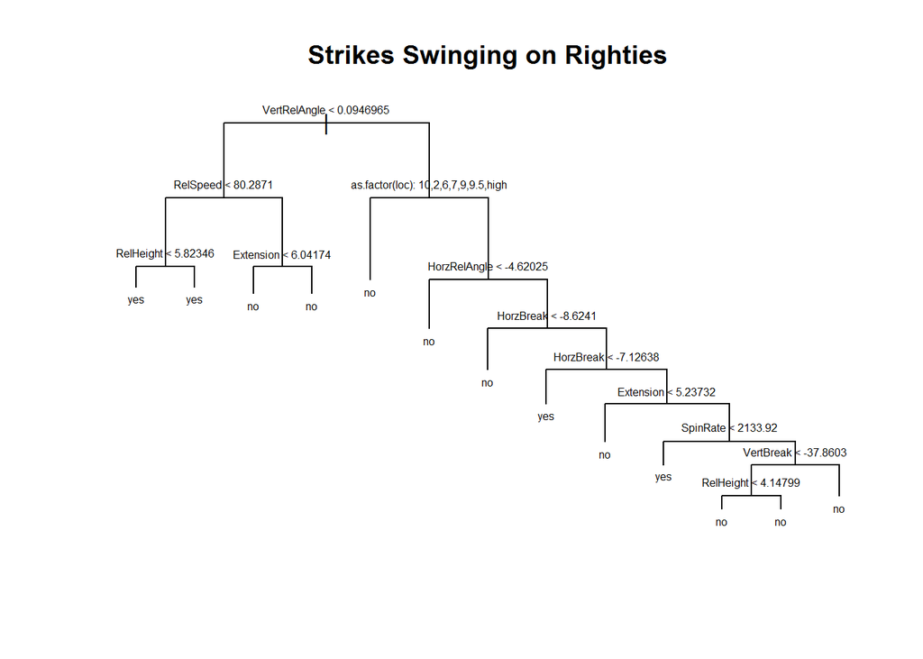

The most important indicator of strikes swinging on lefties is location, with pitches more than a ball inside or off of the plate, pitches high middle and outside, middle, low and inside, and above the plate and below the plate resulting in a terminal node. Vertical release angle is the most important indicator for strikes swinging on righties.

### Balls

```
##
## Classification tree:
## tree(formula = as.factor(BallCalled) ~ RelHeight + RelSide +
##     RelSpeed + VertRelAngle + HorzRelAngle + Extension + VertBreak +
##     HorzBreak + SpinRate + SpinAxis + as.factor(type) + as.factor(loc),
##     data = lefties)
## Variables actually used in tree construction:
## [1] "as.factor(loc)" "VertRelAngle"   "VertBreak"      "SpinRate"
## Number of terminal nodes:  9
## Residual mean deviance:  0.3289 = 36.18 / 110
## Misclassification error rate: 0.07563 = 9 / 119
```

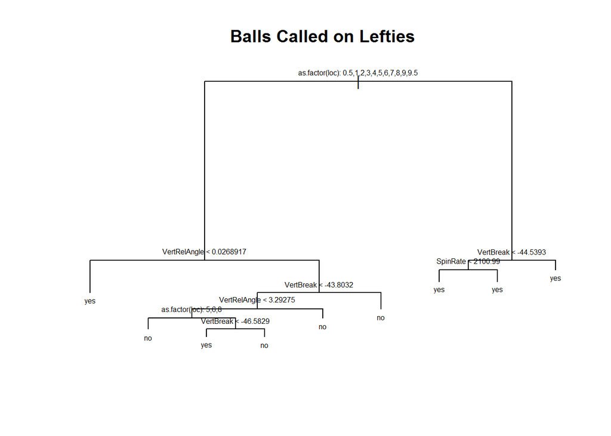

```
##
## Classification tree:
## tree(formula = as.factor(BallCalled) ~ RelHeight + RelSide +
##     RelSpeed + VertRelAngle + HorzRelAngle + Extension + VertBreak +
##     HorzBreak + SpinRate + SpinAxis + as.factor(type) + as.factor(loc),
##     data = righties)
## Variables actually used in tree construction:
## [1] "as.factor(loc)" "HorzRelAngle"   "RelSide"        "RelSpeed"
## [5] "HorzBreak"      "VertRelAngle"
## Number of terminal nodes:  12
## Residual mean deviance:  0.2724 = 38.14 / 140
## Misclassification error rate: 0.05263 = 8 / 152
```

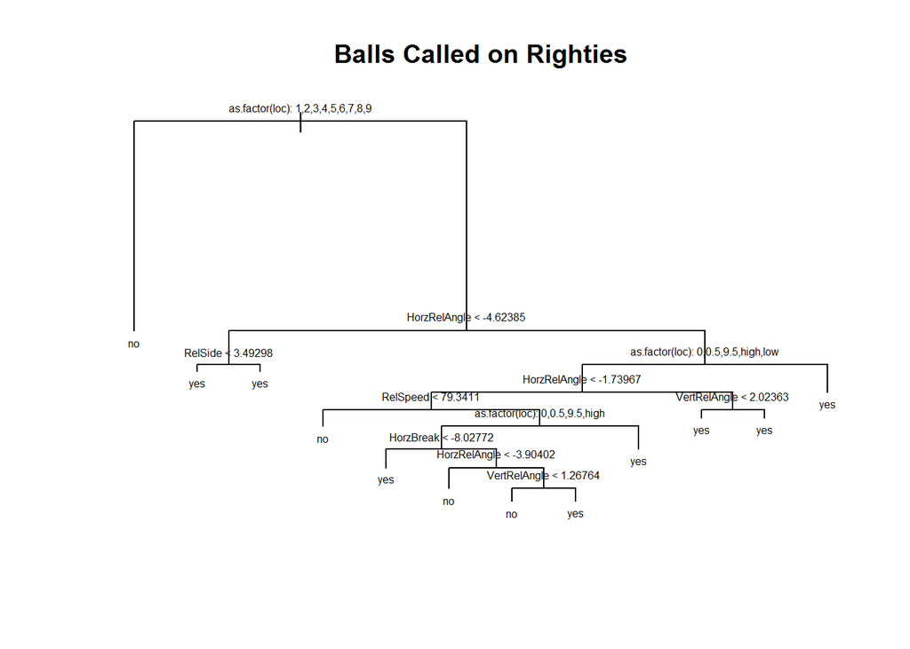

The most important indicator of a pitch being called a ball on a leftie is location. Location is also the most important factor for a ball being called on a rightie, with any pitch being thrown in the strike zone resulting in a terminal node.

### BHIP Outs

```
##
## Classification tree:
## tree(formula = as.factor(Out) ~ RelHeight + RelSide + RelSpeed +
##     VertRelAngle + HorzRelAngle + Extension + VertBreak + HorzBreak +
##     SpinRate + SpinAxis + as.factor(type) + as.factor(loc), data = lefties)
## Variables actually used in tree construction:
## [1] "as.factor(loc)" "VertBreak"      "HorzRelAngle"   "RelSpeed"
## Number of terminal nodes:  6
## Residual mean deviance:  0.2634 = 29.76 / 113
## Misclassification error rate: 0.06723 = 8 / 119
```

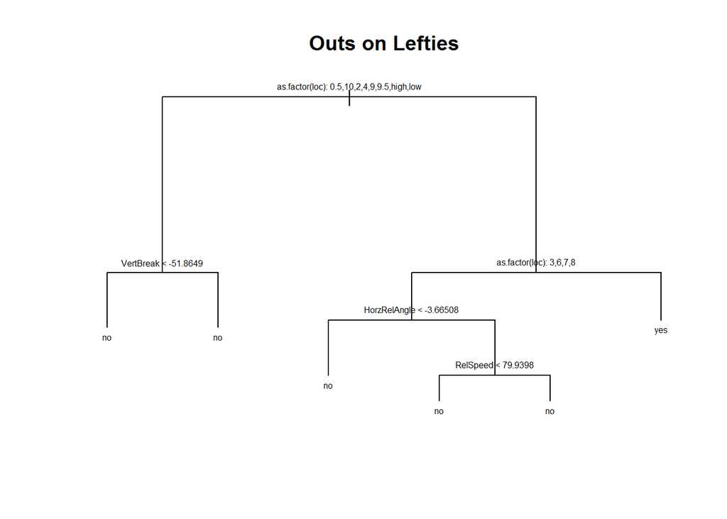

```
##
## Classification tree:
## tree(formula = as.factor(Out) ~ RelHeight + RelSide + RelSpeed +
##     VertRelAngle + HorzRelAngle + Extension + VertBreak + HorzBreak +
##     SpinRate + SpinAxis + as.factor(type) + as.factor(loc), data = righties)
## Variables actually used in tree construction:
## [1] "as.factor(loc)" "SpinRate"       "SpinAxis"       "RelSide"
## [5] "RelHeight"
## Number of terminal nodes:  7
## Residual mean deviance:  0.2054 = 29.79 / 145
## Misclassification error rate: 0.05263 = 8 / 152
```

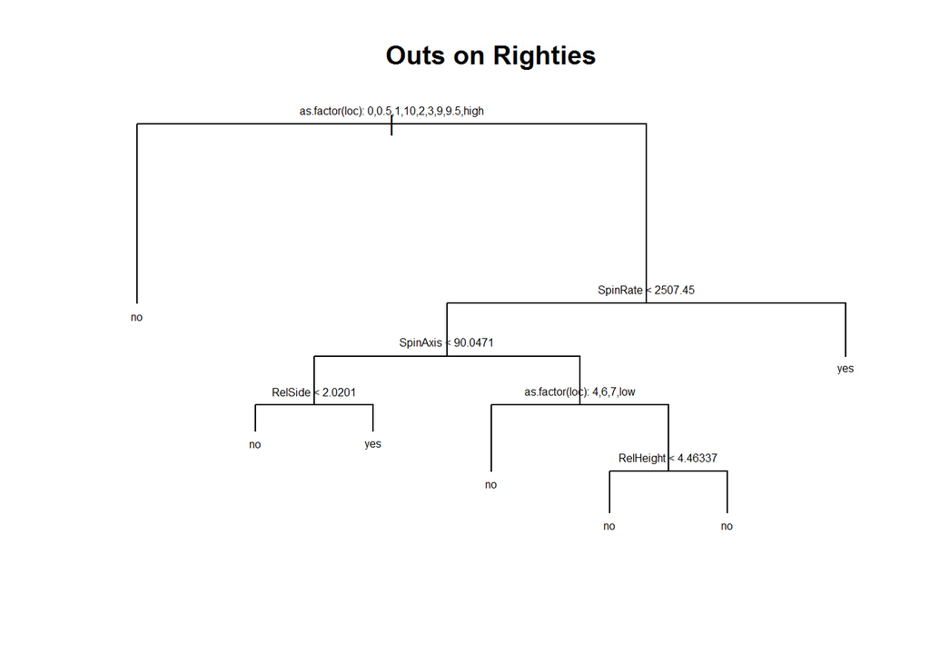

Location is the most important indicator of outs on lefties, with pitches more than a ball inside, high and inside, and down the middle of the plate resulting in a postive node. Location is also the most important indicator of outs on a rightie, with pitches inside or off of the plate, high in the strike zone, low and in, and above the strike zone resulting in a terminal node.

### Hits

```
##
## Classification tree:
## tree(formula = as.factor(Hit) ~ RelHeight + RelSide + RelSpeed +
##     VertRelAngle + HorzRelAngle + Extension + VertBreak + HorzBreak +
##     SpinRate + SpinAxis + as.factor(type) + as.factor(loc), data = lefties)
## Variables actually used in tree construction:
## [1] "as.factor(loc)" "HorzRelAngle"   "VertRelAngle"   "Extension"
## [5] "RelHeight"
## Number of terminal nodes:  8
## Residual mean deviance:  0.2196 = 24.38 / 111
## Misclassification error rate: 0.05042 = 6 / 119
```

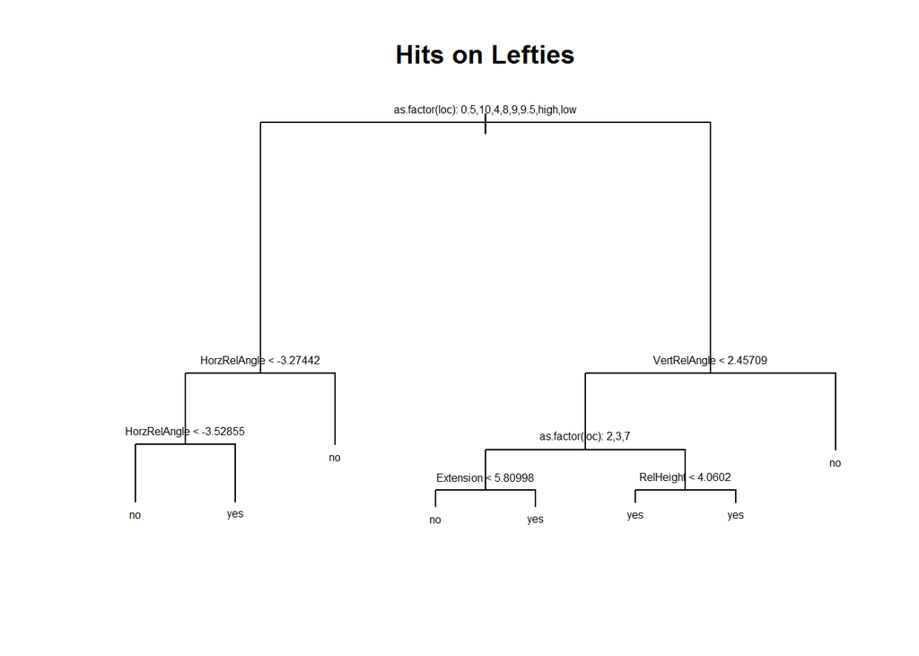

```
##
## Classification tree:
## tree(formula = as.factor(Hit) ~ RelHeight + RelSide + RelSpeed +
##     VertRelAngle + HorzRelAngle + Extension + VertBreak + HorzBreak +
##     SpinRate + SpinAxis + as.factor(type) + as.factor(loc), data = righties)
## Variables actually used in tree construction:
## [1] "as.factor(loc)" "Extension"      "HorzBreak"      "RelSpeed"
## [5] "HorzRelAngle"   "VertBreak"
## Number of terminal nodes:  10
## Residual mean deviance:  0.185 = 26.27 / 142
## Misclassification error rate: 0.03947 = 6 / 152
```

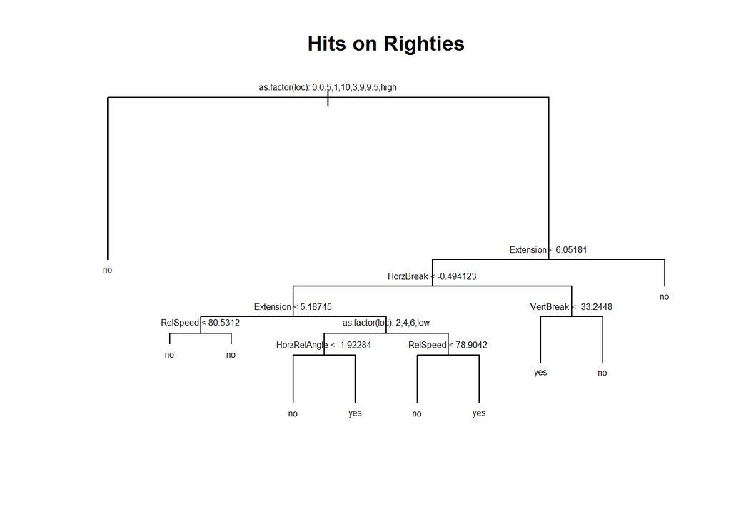

Location is the most important indicator of hits for both lefties and righties. For righties, pitches off or inside of the plate, high and outside, high and inside, and above the strike zone result in a terminal node, meaning that they are not being hit.

## Prediction with Pitcher Controllable Variables

### Called Strikes

```
##
## Classification tree:
## tree(formula = as.factor(StrikeCalled) ~ RelHeight + RelSpeed +
##     Extension + VertBreak + HorzBreak + as.factor(type) + as.factor(loc) +
##     SpinAxis, data = lefties)
## Variables actually used in tree construction:
## [1] "as.factor(loc)" "Extension"      "HorzBreak"      "SpinAxis"
## [5] "RelSpeed"       "RelHeight"
## Number of terminal nodes:  12
## Residual mean deviance:  0.3439 = 41.96 / 122
## Misclassification error rate: 0.06716 = 9 / 134
```

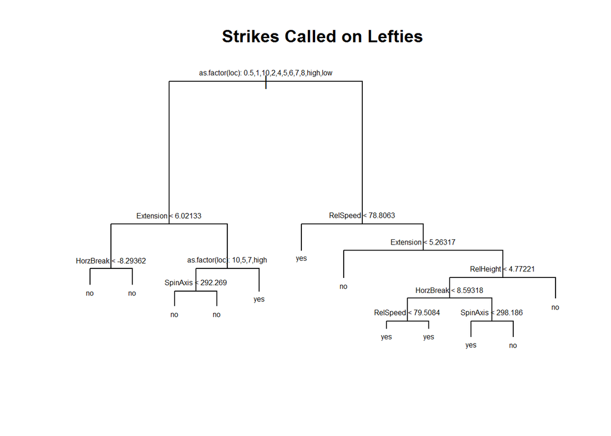

```
##
## Classification tree:
## tree(formula = as.factor(StrikeCalled) ~ RelHeight + RelSpeed +
##     Extension + VertBreak + HorzBreak + as.factor(type) + as.factor(loc) +
##     SpinAxis, data = righties)
## Variables actually used in tree construction:
## [1] "as.factor(loc)" "HorzBreak"      "RelSpeed"       "VertBreak"
## [5] "RelHeight"
## Number of terminal nodes:  18
## Residual mean deviance:  0.478 = 87.47 / 183
## Misclassification error rate: 0.1095 = 22 / 201
```

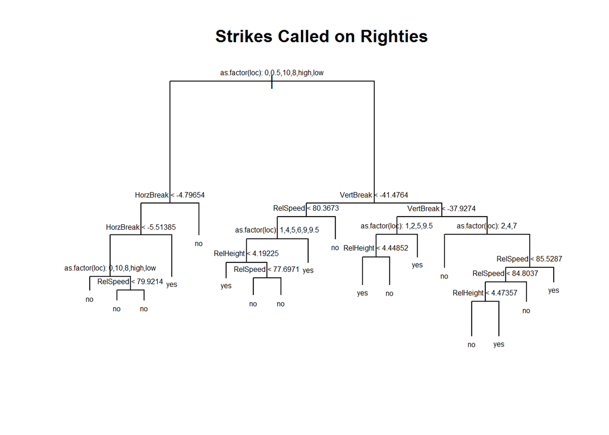

### Strikes Swinging

```
##
## Classification tree:
## tree(formula = as.factor(StrikeSwinging) ~ RelHeight + RelSpeed +
##     Extension + VertBreak + HorzBreak + as.factor(type) + as.factor(loc) +
##     SpinAxis, data = lefties)
## Variables actually used in tree construction:
## [1] "as.factor(loc)" "Extension"      "RelSpeed"       "RelHeight"
## Number of terminal nodes:  7
## Residual mean deviance:  0.2078 = 26.39 / 127
## Misclassification error rate: 0.04478 = 6 / 134
```

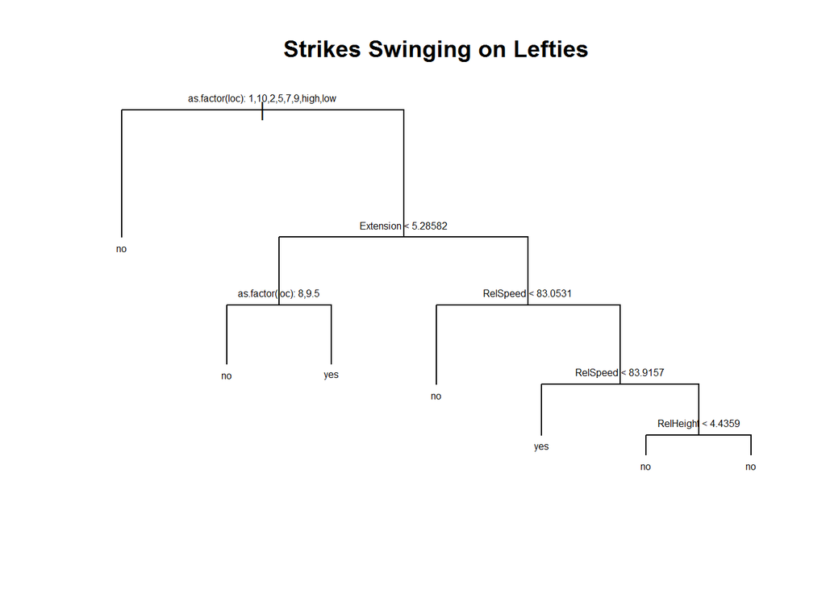

```
##
## Classification tree:
## tree(formula = as.factor(StrikeSwinging) ~ RelHeight + RelSpeed +
##     Extension + VertBreak + HorzBreak + as.factor(type) + as.factor(loc) +
##     SpinAxis, data = righties)
## Variables actually used in tree construction:
## [1] "as.factor(loc)" "Extension"      "HorzBreak"      "VertBreak"
## [5] "RelSpeed"       "RelHeight"
## Number of terminal nodes:  18
## Residual mean deviance:  0.3759 = 68.8 / 183
## Misclassification error rate: 0.09453 = 19 / 201
```

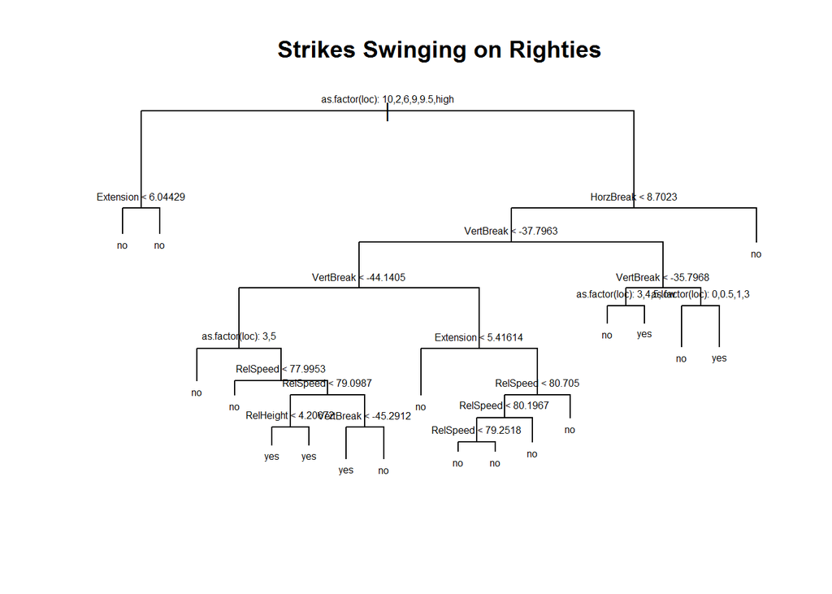

### Balls

```
##
## Classification tree:
## tree(formula = as.factor(BallCalled) ~ RelHeight + RelSpeed +
##     Extension + VertBreak + HorzBreak + as.factor(type) + as.factor(loc) +
##     SpinAxis, data = lefties)
## Variables actually used in tree construction:
## [1] "as.factor(loc)" "RelHeight"      "VertBreak"      "RelSpeed"
## [5] "Extension"
## Number of terminal nodes:  7
## Residual mean deviance:  0.3302 = 41.94 / 127
## Misclassification error rate: 0.08209 = 11 / 134
```

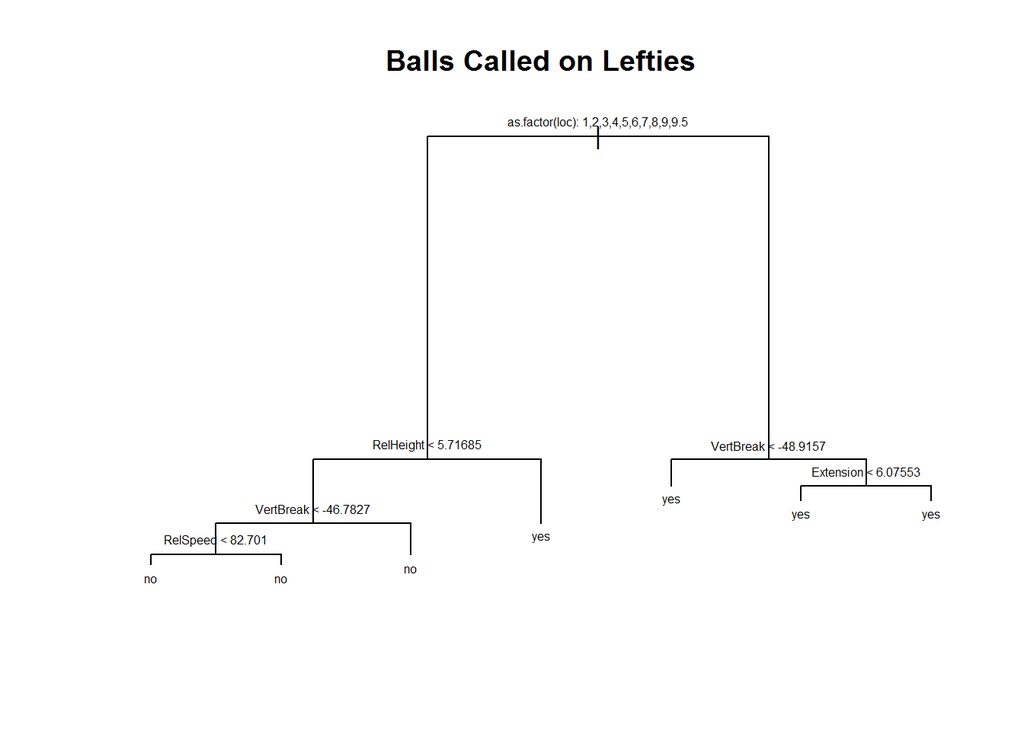

```
##
## Classification tree:
## tree(formula = as.factor(BallCalled) ~ RelHeight + RelSpeed +
##     Extension + VertBreak + HorzBreak + as.factor(type) + as.factor(loc) +
##     SpinAxis, data = righties)
## Variables actually used in tree construction:
## [1] "as.factor(loc)" "SpinAxis"       "VertBreak"      "HorzBreak"
## [5] "RelHeight"
## Number of terminal nodes:  13
## Residual mean deviance:  0.4109 = 77.25 / 188
## Misclassification error rate: 0.09453 = 19 / 201
```

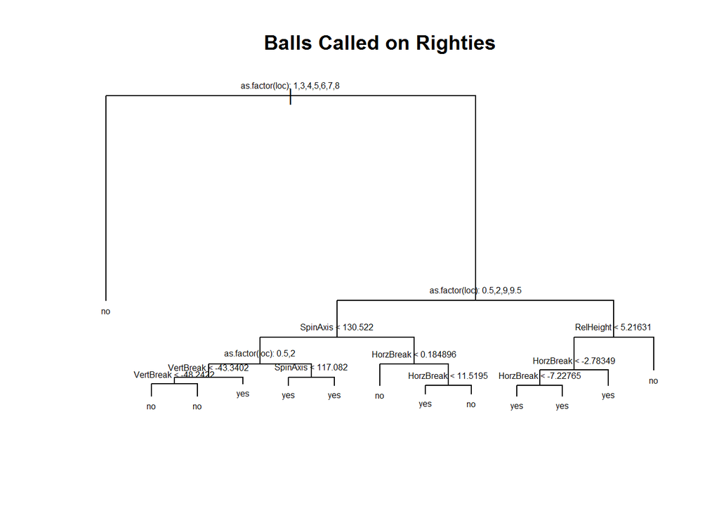

### BHIP Outs

```
##
## Classification tree:
## tree(formula = as.factor(Out) ~ RelHeight + RelSpeed + Extension +
##     VertBreak + HorzBreak + as.factor(type) + as.factor(loc) +
##     SpinAxis, data = lefties)
## Variables actually used in tree construction:
## [1] "as.factor(loc)" "VertBreak"      "Extension"      "SpinAxis"
## Number of terminal nodes:  7
## Residual mean deviance:  0.2577 = 32.73 / 127
## Misclassification error rate: 0.0597 = 8 / 134
```

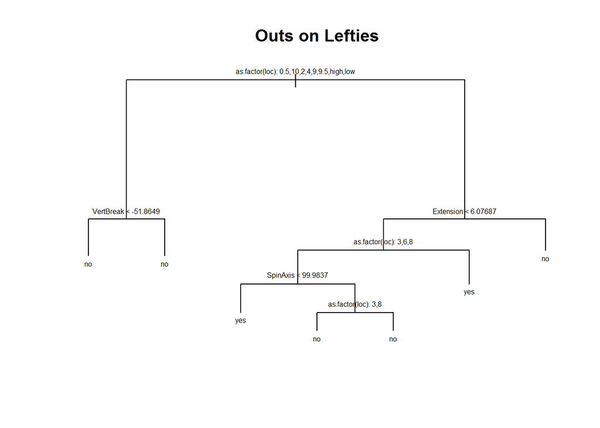

```
##
## Classification tree:
## tree(formula = as.factor(Out) ~ RelHeight + RelSpeed + Extension +
##     VertBreak + HorzBreak + as.factor(type) + as.factor(loc) +
##     SpinAxis, data = righties)
## Variables actually used in tree construction:
## [1] "as.factor(loc)" "SpinAxis"       "VertBreak"      "Extension"
## [5] "RelHeight"      "RelSpeed"       "HorzBreak"
## Number of terminal nodes:  12
## Residual mean deviance:  0.2403 = 45.42 / 189
## Misclassification error rate: 0.05473 = 11 / 201
```

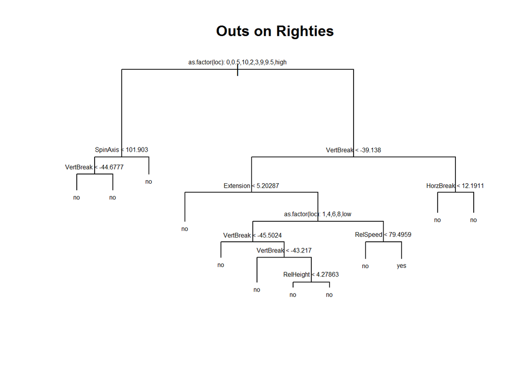

### Hits

```
##
## Classification tree:
## tree(formula = as.factor(Hit) ~ RelHeight + RelSpeed + Extension +
##     VertBreak + HorzBreak + as.factor(type) + as.factor(loc) +
##     SpinAxis, data = lefties)
## Variables actually used in tree construction:
## [1] "as.factor(loc)" "VertBreak"      "RelSpeed"       "RelHeight"
## [5] "SpinAxis"       "HorzBreak"
## Number of terminal nodes:  9
## Residual mean deviance:  0.2913 = 36.41 / 125
## Misclassification error rate: 0.08209 = 11 / 134
```

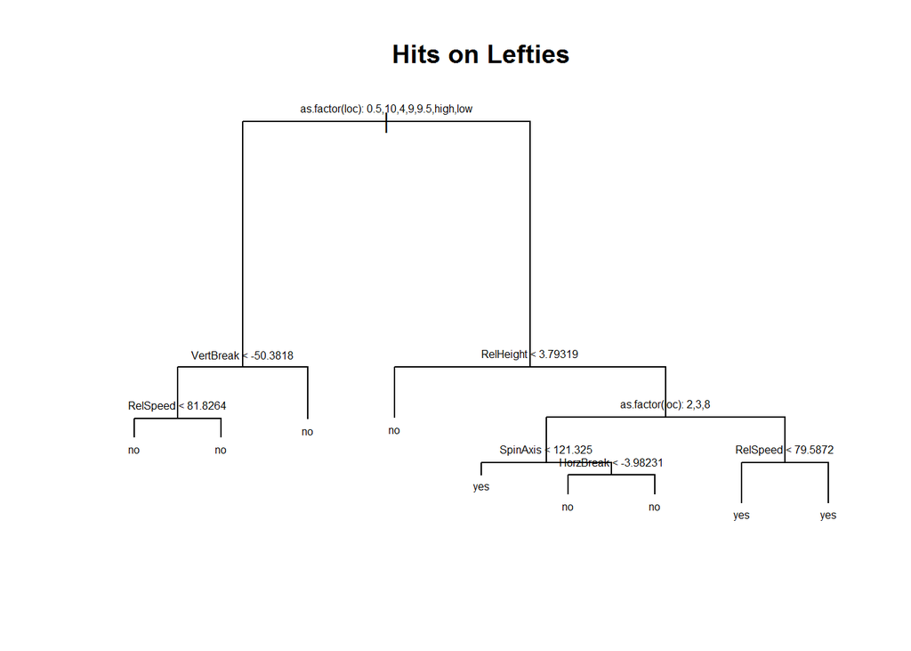

```
##
## Classification tree:
## tree(formula = as.factor(Hit) ~ RelHeight + RelSpeed + Extension +
##     VertBreak + HorzBreak + as.factor(type) + as.factor(loc),
##     data = righties)
## Variables actually used in tree construction:
## [1] "as.factor(loc)" "VertBreak"      "Extension"      "RelSpeed"
## [5] "RelHeight"      "HorzBreak"
## Number of terminal nodes:  14
## Residual mean deviance:  0.241 = 45.06 / 187
## Misclassification error rate: 0.04975 = 10 / 201
```

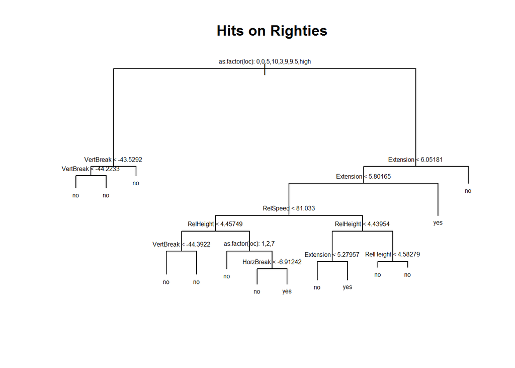